# Scraping data from Twitter’s Streaming API

Pablo Barbera

January 31, 2017

### Scraping web data from Twitter

#### Authenticating

Follow these steps to create your token:

1. Go to apps.twitter.com and sign in.
2. Click on “Create New App”. You will need to have a phone number associated with your account in order to be able to create a token.
3. Fill name, description, and website (it can be anything, even http://www.google.com). Make sure you leave ‘Callback URL’ empty.
4. Agree to user conditions.
5. From the “Keys and Access Tokens” tab, copy consumer key and consumer secret and paste below

```r
#install.packages("ROAuth")
library(ROAuth)
requestURL <- "https://api.twitter.com/oauth/request_token"
accessURL <- "https://api.twitter.com/oauth/access_token"
authURL <- "https://api.twitter.com/oauth/authorize"
consumerKey <- "8rhE418Fd7AXgzi0XKJzmGmL5"
consumerSecret <- "N7ZqM2sLyPCmChbuj6iSElNS0EqrXt1dcM3DOYPtm4K78ACAoe"

my_oauth <- OAuthFactory$new(consumerKey=consumerKey,
  consumerSecret=consumerSecret, requestURL=requestURL,
  accessURL=accessURL, authURL=authURL)
```

Run the below line and go to the URL that appears on screen. Then, type the PIN into the console (RStudio sometimes doesn’t show what you’re typing, but it’s there!)

```r
my_oauth$handshake(cainfo = system.file("CurlSSL", "cacert.pem", package = "RCurl"))
```

Now you can save oauth token for use in future sessions with netdemR or streamR. Make sure you save it in a folder where this is the only file.

```r
save(my_oauth, file="credentials/twitter-token-2.Rdata")
```

#### Collecting data from Twitter’s Streaming API

Collecting tweets filtering by keyword:

```r
#install.packages("streamR")
library(streamR)
load("credentials/twitter-token-2.Rdata")
filterStream(file.name="trump-tweets.json", track="trump",
    timeout=20, oauth=my_oauth)
```

```
## Capturing tweets...
```

```
## Connection to Twitter stream was closed after 20 seconds with up to 2897 tweets downloaded.
```

Note the options: - `file.name` indicates the file in your disk where the tweets will be downloaded  
- `track` is the keyword(s) mentioned in the tweets we want to capture. - `timeout` is the number of seconds that the connection will remain open  
- `oauth` is the OAuth token we are using

Once it has finished, we can open it in R as a data frame with the `parseTweets` function

```r
tweets <- parseTweets("trump-tweets.json")
```

```
## 1915 tweets have been parsed.
```

```r
str(tweets)
```

```
## 'data.frame':    1915 obs. of  43 variables:
##  $ text                     : chr  "Trump immigration ban draws global outcry https://t.co/3RlzSToGHj https://t.co/X9cuCGlbfJ" "RT @katewerk: If you're confused about media attacks on Trump for #QuebecMosqueAttack - you've forgotten the time when @SarahPa"| __truncated__ "RT @PlanetofFinks: It to…
##  $ retweet_count            : num  0 0 0 0 0 0 0 0 0 0 ...
##  $ favorite_count           : num  0 0 0 0 0 0 0 0 0 0 ...
##  $ favorited                : logi  FALSE FALSE FALSE FALSE FALSE FALSE ...
##  $ truncated                : logi  FALSE FALSE FALSE FALSE FALSE FALSE ...
##  $ id_str                   : chr  "826484633395097605" "826484634322038785" "826484634032668681" "826484633973911555" ...
##  $ in_reply_to_screen_name  : chr  NA NA NA NA ...
##  $ source                   : chr  "<a href=\"https://dlvrit.com/\" rel=\"nofollow\">dlvr.it</a>" "<a href=\"http://twitter.com/download/iphone\" rel=\"nofollow\">Twitter for iPhone</a>" "<a href=\"http://twitter.com/download/iphone\" rel=\"nofollow\">Twitter for iPhone</a>" "<a href=\"https://dl…
##  $ retweeted                : logi  FALSE FALSE FALSE FALSE FALSE FALSE ...
##  $ created_at               : chr  "Tue Jan 31 17:37:46 +0000 2017" "Tue Jan 31 17:37:46 +0000 2017" "Tue Jan 31 17:37:46 +0000 2017" "Tue Jan 31 17:37:46 +0000 2017" ...
##  $ in_reply_to_status_id_str: chr  NA NA NA NA ...
##  $ in_reply_to_user_id_str  : chr  NA NA NA NA ...
##  $ lang                     : chr  "en" "en" "en" "en" ...
##  $ listed_count             : num  681 11 1 21 3 2 5 37 2 12 ...
```

[output cut: 29 more lines]

```r
tweets[1,]
```

```
##                                                                                        text
## 1 Trump immigration ban draws global outcry https://t.co/3RlzSToGHj https://t.co/X9cuCGlbfJ
##   retweet_count favorite_count favorited truncated             id_str
## 1             0              0     FALSE     FALSE 826484633395097605
##   in_reply_to_screen_name
## 1                    <NA>
##                                                     source retweeted
## 1 <a href="https://dlvrit.com/" rel="nofollow">dlvr.it</a>     FALSE
##                       created_at in_reply_to_status_id_str
## 1 Tue Jan 31 17:37:46 +0000 2017                      <NA>
##   in_reply_to_user_id_str lang listed_count verified
## 1                    <NA>   en          681    FALSE
##                    location user_id_str
## 1 Las Vegas, NV, USA, World    49546535
##                                                                                                description
## 1 Promoter, Science, Unix, Linux, FOSS, Tech, Hack, OS + Wine geek!  What excites you? Twitter excites me!
##   geo_enabled                user_created_at statuses_count
## 1       FALSE Mon Jun 22 05:25:54 +0000 2009         154455
##   followers_count favourites_count protected
## 1          318929              301     FALSE
##                             user_url     name                  time_zone
## 1 https://www.instagram.com/tsairox/ Tsai Rox Pacific Time (US & Canada)
##   user_lang utc_offset friends_count screen_name country_code country
## 1        en     -28800         80324     tsairox         <NA>    <NA>
##   place_type full_name place_name place_id place_lat place_lon lat lon
## 1       <NA>      <NA>       <NA>     <NA>       NaN       NaN  NA  NA
##            expanded_url                     url
## 1 http://dlvr.it/NFkNjq https://t.co/3RlzSToGHj
```

If we want, we could also export it to a csv file to be opened later with Excel

```r
write.csv(tweets, file="trump-tweets.csv", row.names=FALSE)
```

And this is how we would capture tweets mentioning multiple keywords:

```r
filterStream(file.name="politics-tweets.json",
    track=c("graham", "sessions", "trump", "clinton"),
    tweets=20, oauth=my_oauth)
```

Note that here I choose a different option, `tweets`, which indicates how many tweets (approximately) the function should capture before we close the connection to the Twitter API.

This second example shows how to collect tweets filtering by location instead. In other words, we can set a geographical box and collect only the tweets that are coming from that area.

For example, imagine we want to collect tweets from the United States. The way to do it is to find two pairs of coordinates (longitude and latitude) that indicate the southwest corner AND the northeast corner. Note the reverse order: it’s not (lat, long), but (long, lat).

In the case of the US, it would be approx. (-125,25) and (-66,50). How to find these coordinates? I use: `http://itouchmap.com/latlong.html`

```r
filterStream(file.name="tweets_geo.json", locations=c(-125, 25, -66, 50),
    timeout=30, oauth=my_oauth)
```

```
## Capturing tweets...
```

[output not shown]

We can do as before and open the tweets in R

```r
tweets <- parseTweets("tweets_geo.json")
```

```
## 3650 tweets have been parsed.
```

And use the maps library to see where most tweets are coming from. Note that there are two types of geographic information on tweets: `lat`/`lon` (from geolocated tweets) and `place_lat` and `place_lon` (from tweets with place information). We will work with whatever is available.

```r
library(maps)
tweets$lat <- ifelse(is.na(tweets$lat), tweets$place_lat, tweets$lat)
tweets$lon <- ifelse(is.na(tweets$lon), tweets$place_lon, tweets$lon)
states <- map.where("state", tweets$lon, tweets$lat)
head(sort(table(states), decreasing=TRUE))
```

```
## states
##   california        texas      florida         ohio     illinois
##          415          375          188          165          128
## pennsylvania
##          123
```

We can also prepare a map of the exact locations of the tweets.

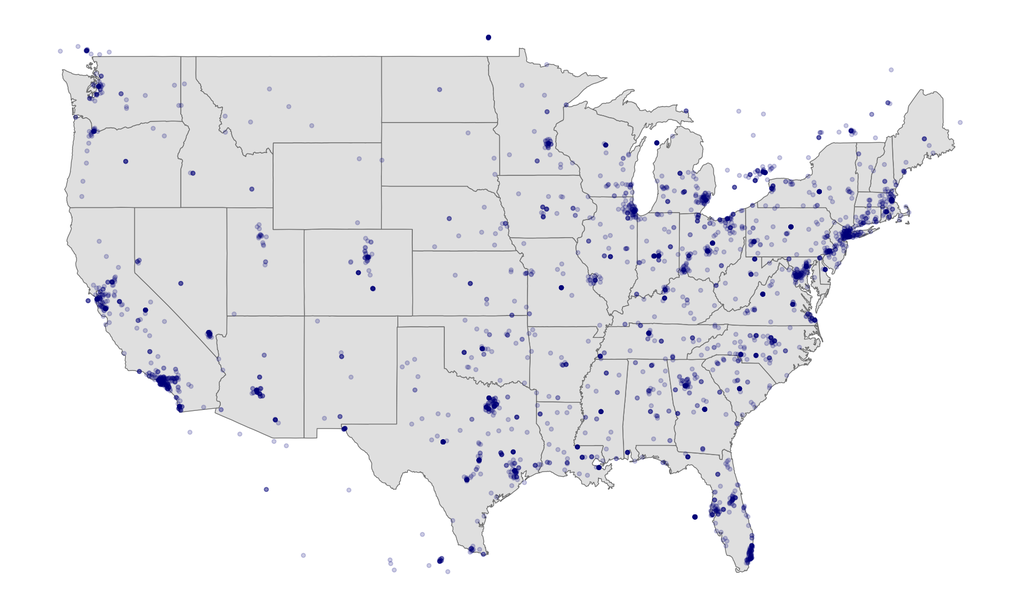

```r
#install.packages("ggplot2")
library(ggplot2)
## First create a data frame with the map data
map.data <- map_data("state")

# And we use ggplot2 to draw the map:
# 1) map base
ggplot(map.data) + geom_map(aes(map_id = region), map = map.data, fill = "grey90",
    color = "grey50", size = 0.25) + expand_limits(x = map.data$long, y = map.data$lat) +
    # 2) limits for x and y axis
    scale_x_continuous(limits=c(-125,-66)) + scale_y_continuous(limits=c(25,50)) +
    # 3) adding the dot for each tweet
    geom_point(data = tweets,
    aes(x = lon, y = lat), size = 1, alpha = 1/5, color = "darkblue") +
    # 4) removing unnecessary graph elements
    theme(axis.line = element_blank(),
        axis.text = element_blank(),
        axis.ticks = element_blank(),
        axis.title = element_blank(),
        panel.background = element_blank(),
        panel.border = element_blank(),
        panel.grid.major = element_blank(),
        panel.grid.minor = element_blank(),
        plot.background = element_blank())
```

Finally, it’s also possible to collect a random sample of tweets. That’s what the “sampleStream” function does:

```r
sampleStream(file.name="tweets_random.json", timeout=30, oauth=my_oauth)
```

```
## Capturing tweets...
```

```
## Connection to Twitter stream was closed after 30 seconds with up to 3136 tweets downloaded.
```

Here I’m collecting 30 seconds of tweets. And once again, to open the tweets in R…

```r
tweets <- parseTweets("tweets_random.json")
```

```
## 2470 tweets have been parsed.
```

What is the most retweeted tweet?

```r
tweets[which.max(tweets$retweet_count),]
```

```
##                                                                             text
## 1 আজকের দিনটি আপনার কেমন যাবে?\n https://t.co/tI5Aqtgje8 https://t.co/4R52TgklYO
##   retweet_count favorite_count favorited truncated             id_str
## 1             0              0     FALSE     FALSE 826484864358690816
##   in_reply_to_screen_name
## 1                    <NA>
##                                                           source retweeted
## 1 <a href="http://sknews24.com/" rel="nofollow">SKNEWS24.COM</a>     FALSE
##                       created_at in_reply_to_status_id_str
## 1 Tue Jan 31 17:38:41 +0000 2017                      <NA>
##   in_reply_to_user_id_str lang listed_count verified   location
## 1                    <NA>   bn            0    FALSE Bangladesh
##          user_id_str
## 1 794759727334862848
##                                                                                                                             description
## 1 অনুকরণ নয়, অনুসরণ নয়, নিজেকে খুঁজুন, নিজেকে জানুন, নিজের পথে চলুন॥--\nImitation is not followed, in itself, Know yourself, going on his way.
##   geo_enabled                user_created_at statuses_count
## 1       FALSE Sat Nov 05 04:34:19 +0000 2016            250
##   followers_count favourites_count protected             user_url
## 1              11               27     FALSE http://sknews24.com/
##           name time_zone user_lang utc_offset friends_count screen_name
## 1 SKNEWS24.COM      <NA>        en         NA           141    SKNEWS24
##   country_code country place_type full_name place_name place_id place_lat
## 1         <NA>    <NA>       <NA>      <NA>       <NA>     <NA>       NaN
##   place_lon lat lon                      expanded_url
## 1       NaN  NA  NA http://sknews24.com/archives/1664
##                       url
## 1 https://t.co/tI5Aqtgje8
```

What are the most popular hashtags at the moment? We’ll use regular expressions to extract hashtags.

```r
library(stringr)
ht <- str_extract_all(tweets$text, "#(\\d|\\w)+")
ht <- unlist(ht)
head(sort(table(ht), decreasing = TRUE))
```

```
## ht
##       #iHeartAwards        #BestFanArmy        #izmirescort
##                  19                  16                  10
## #유우카_고양이_기원    #JeChoisisMarine        #gameinsight
##                   9                   6                   5
```

How many tweets mention Justin Bieber?

```r
length(grep("bieber", tweets$text, ignore.case=TRUE))
```

```
## [1] 2
```